# introduccion

## I N T R O D U C C I Ó N

Cada programador tiene una historia sobre cómo aprendió a escribir su primer programa. Comencé a programar cuando era niño, mientras mi padre trabajaba para Digital Equipment Corporation, una de las empresas pioneras de la era moderna de la computación. Escribí mi primer programa en un computador de kit que mi padre había ensamblado en nuestro sótano. El computador consistía únicamente en una placa base conectada a un teclado sin carcasa, y su monitor era un simple tubo de rayos catódicos expuesto. Mi programa inicial fue un simple juego de adivinanza de números, que lucía algo como esto:

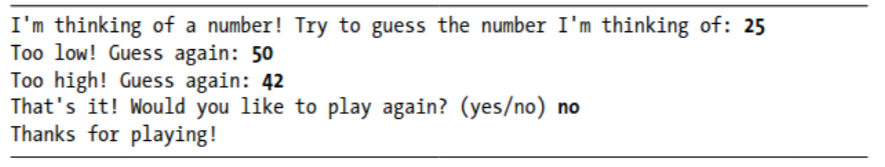

Siempre recordaré la satisfacción que sentí al ver a mi familia jugar un juego que creé y que funcionaba tal como lo había planeado. Esa primera experiencia tuvo un impacto duradero. Hay una verdadera satisfacción en construir algo con un propósito, que resuelve un problema. El software que escribo ahora cubre necesidades mucho más significativas que mis esfuerzos infantiles, pero la sensación de satisfacción que obtengo al crear un programa que funciona sigue siendo, en gran medida, la misma.

## ¿Para Quién Es Este Libro?

El objetivo de este libro es ayudarte a ponerte al día con Python lo más rápido posible para que puedas crear programas funcionales: juegos, visualizaciones de datos y aplicaciones web, mientras desarrollas una base sólida en programación que te servirá durante toda tu vida. Python Crash Course está escrito para personas de cualquier edad que nunca hayan programado en Python o que nunca hayan programado en absoluto. Este libro es para quienes desean aprender los conceptos básicos de programación de manera rápida para enfocarse en proyectos interesantes, y para aquellos que disfrutan de probar su comprensión resolviendo problemas significativos. Python Crash Course también es perfecto para docentes de todos los niveles que quieran ofrecer a sus estudiantes una introducción a la programación basada en proyectos. Si estás tomando una clase universitaria y quieres una introducción más amigable a Python que el texto que te asignaron, este libro puede facilitarte la clase. Si estás buscando cambiar de carrera, Python Crash Course puede ayudarte en la transición hacia una carrera más satisfactoria. Ha funcionado bien para una amplia variedad de lectores con una gama de objetivos diversos.

## ¿Qué Puedes Esperar Aprender?

El propósito de este libro es convertirte en un buen programador en general y en un buen programador de Python en particular. Aprenderás de manera eficiente y adoptarás buenos hábitos mientras adquieres una base sólida en conceptos generales de programación. Después de trabajar en este libro, deberías estar listo para avanzar hacia técnicas más avanzadas de Python, y tu próximo lenguaje de programación será aún más fácil de aprender.

## Parte I: Conceptos Básicos de Programación en Python

En la primera parte del libro aprenderás los conceptos básicos de programación necesarios para escribir programas en Python. Estos conceptos son los mismos que aprenderías al comenzar en casi cualquier lenguaje de programación. Aprenderás sobre diferentes tipos de datos y las formas en que puedes almacenarlos en tus programas. Construirás colecciones de datos, como listas y diccionarios, y trabajarás a través de esas colecciones de maneras eficientes. Descubrirás cómo usar bucles while y sentencias if para comprobar ciertas condiciones y ejecutar secciones específicas de código según esas condiciones. Esto te ayudará a automatizar muchos procesos. Aprenderás a aceptar entradas del usuario para hacer tus programas interactivos y a mantener tus programas en ejecución mientras el usuario lo desee. Explorarás cómo escribir funciones que hagan que las partes de tu programa sean reutilizables, lo que te permitirá escribir bloques de código una sola vez y reutilizarlos cuando lo necesites. Luego, extenderás este concepto para crear clases que permitan que tus programas manejen comportamientos más complicados. También aprenderás a manejar errores comunes de manera elegante. Después de trabajar con estos conceptos básicos, escribirás varios programas cada vez más complejos. Finalmente, darás tu primer paso hacia la programación intermedia aprendiendo a escribir pruebas para tu código, para que puedas continuar desarrollando tus programas sin preocuparte por introducir errores.

## Parte II: Proyectos Prácticos

En la segunda parte del libro, aplicarás lo que aprendiste en la primera parte para trabajar en tres proyectos. Puedes hacer cualquiera de los proyectos o todos, en el orden que prefieras.

- Proyecto 1: Juego de Disparos “Alien Invasion” (Capítulos 12-14) Crearás un juego de disparos estilo Space Invaders con varios niveles de dificultad creciente. Después de completar este proyecto, estarás bien encaminado para desarrollar tus propios juegos 2D. Incluso si no aspiras a convertirte en programador de juegos, trabajar en este proyecto es una forma divertida de reunir gran parte de lo que aprenderás en la primera parte.
- Proyecto 2: Visualización de Datos (Capítulos 15-17) Este proyecto te introduce a la visualización de datos. Los científicos de datos usan una variedad de técnicas de visualización para dar sentido a la gran cantidad de información disponible. Trabajarás con conjuntos de datos que generarás a través de código, que descargarás de fuentes en línea y que tus programas descargarán automáticamente. Después de completar este proyecto, serás capaz de escribir programas que analicen grandes conjuntos de datos y que generen representaciones visuales de diferentes tipos de información.
- Proyecto 3: Aplicación Web “Learning Log” (Capítulos 18-20) Construirás una aplicación web llamada Learning Log, que te permitirá llevar un diario organizado de la información que has aprendido sobre un tema específico. Podrás llevar registros separados para diferentes temas y permitir que otros usuarios creen una cuenta y comiencen sus propios diarios. También aprenderás a desplegar tu proyecto en línea, para que cualquiera pueda acceder a él desde cualquier parte del mundo.

## Recursos en Línea

La editorial No Starch Press ofrece información adicional sobre este libro en línea en: 🔗 https://nostarch.com/python-crash-course-3rd-edition Además, el autor mantiene un extenso conjunto de recursos complementarios en: 🔗 https://ehmatthes.github.io/pcc_3e Estos recursos incluyen: Instrucciones de configuración con enlaces activos para todos los pasos. Actualizaciones del libro, ya que Python, como todos los lenguajes, está en constante evolución. Hojas de referencia (cheat sheets) descargables para consulta rápida de conceptos importantes.

# PARTE I

## B Á S I C O S

La Parte I de este libro te enseñará los conceptos básicos necesarios para escribir programas en Python. Muchos de estos conceptos son comunes a todos los lenguajes de programación, por lo que serán útiles durante toda tu carrera como programadora.

### Capítulo 1: Instalación de Python y Primer Programa

En el Capítulo 1, instalarás Python en tu computadora y ejecutarás tu primer programa, que imprimirá el mensaje Hello world! en la pantalla.

### Capítulo 2: Variables y Tipos de Datos

En el Capítulo 2, aprenderás a asignar información a variables y a trabajar con valores textuales y numéricos.

### Capítulos 3 y 4: Listas

Los Capítulos 3 y 4 introducen las listas, una estructura que permite almacenar grandes cantidades de información en un solo lugar, lo que facilita el manejo de datos de forma eficiente. Con solo unas pocas líneas de código, podrás trabajar con cientos, miles o incluso millones de valores.

### Capítulo 5: Sentencias if (Condicionales)

En el Capítulo 5, utilizarás las sentencias if para escribir código que responda de diferentes maneras según ciertas condiciones.

### Capítulo 6: Diccionarios

El Capítulo 6 te enseñará a utilizar los diccionarios de Python, que te permiten establecer conexiones entre diferentes piezas de información. Al igual que las listas, los diccionarios pueden contener toda la información que necesites almacenar.

### Capítulo 7: Entradas del Usuario y Bucles while

En el Capítulo 7, aprenderás a aceptar entradas del usuario para hacer tus programas interactivos. También aprenderás sobre los bucles while, que ejecutan bloques de código de forma repetitiva mientras se cumplan ciertas condiciones.

### Capítulo 8: Funciones

En el Capítulo 8, escribirás funciones, que son bloques de código reutilizables que realizan tareas específicas y que pueden ejecutarse tantas veces como lo necesites.

### Capítulo 9: Clases y Programación Orientada a Objetos

El Capítulo 9 introduce las clases, que te permiten modelar objetos del mundo real. Escribirás código que represente perros, gatos, personas, autos, cohetes, y más.

### Capítulo 10: Manejo de Archivos y Errores

En el Capítulo 10, aprenderás a trabajar con archivos y a manejar errores para que tus programas no se bloqueen de manera inesperada. Almacenarás datos antes de que tu programa se cierre y podrás leerlos nuevamente cuando el programa se ejecute de nuevo. También aprenderás sobre las excepciones en Python, que te permitirán anticiparte a los errores y hacer que tus programas los manejen de forma elegante.

### Capítulo 11: Pruebas de Código (Testing)

En el Capítulo 11, aprenderás a escribir pruebas para tu código, lo que te permitirá comprobar que tus programas funcionen como lo planeas. Esto te ayudará a expandir tus programas sin preocuparte por introducir nuevos errores. Aprender a probar tu código es una de las primeras habilidades que te ayudará a pasar de programadora principiante a programadora intermedia.

## Comenzando con Python (Getting Started)

En este capítulo, ejecutarás tu primer programa en Python llamado hello_world.py. Primero, necesitarás verificar si tienes una versión reciente de Python instalada en tu computadora; si no es así, la instalarás. También instalarás un editor de texto para trabajar con tus programas en Python. Estos editores reconocen el código Python y resaltan las secciones a medida que escribes, lo que facilita entender la estructura del código.

### Configuración del Entorno de Programación (Setting Up Your Programming Environment)

Python difiere ligeramente según el sistema operativo que uses, por lo que debes tener en cuenta algunas consideraciones. En las siguientes secciones, nos aseguraremos de que Python esté configurado correctamente en tu sistema.

### Versiones de Python (Python Versions)

Todos los lenguajes de programación evolucionan a medida que surgen nuevas ideas y tecnologías, y los desarrolladores de Python han hecho que el lenguaje sea más versátil y poderoso con el tiempo. La última versión de Python, en el momento de escribir este libro, es Python 3.11, pero todo lo que aprendas aquí debería funcionar con Python 3.9 o versiones posteriores. En esta sección, verificaremos si Python ya está instalado en tu sistema y si es necesario instalar una versión más reciente. El Apéndice A contiene detalles adicionales sobre cómo instalar la versión más reciente de Python en cada sistema operativo importante.

Ejecución de Fragmentos de Código en Python (Running Snippets of Python Code) Puedes ejecutar el intérprete de Python en una ventana de terminal, lo que te permitirá probar fragmentos de código sin necesidad de guardar y ejecutar un programa completo. A lo largo de este libro, verás fragmentos de código que lucen así:

```python
print('Hello Python interpreter!')
```

```
Hello Python interpreter!
```

### Los tres corchetes angulares (>>>)

Los tres corchetes angulares ( >>> ), a los que nos referiremos como el prompt de Python, indican que deberías estar usando la ventana de terminal. El texto en negrita es el código que debes escribir y ejecutar presionando ENTER. La mayoría de los ejemplos en este libro son programas pequeños y autónomos que ejecutarás desde tu editor de texto, ya que escribirás la mayoría de tu código ahí. Sin embargo, algunos conceptos básicos se explicarán con una serie de fragmentos de código ejecutados en una sesión de terminal de Python, para demostrar esos conceptos de manera más eficiente. Cuando veas los tres corchetes angulares en un fragmento de código, estarás viendo código y salida de una sesión de terminal.

En un momento, intentaremos escribir código en el intérprete de tu sistema. También usaremos un editor de texto para crear un programa simple llamado Hello World!, que se ha convertido en una tradición al aprender a programar. Existe una tradición en el mundo de la programación que dice que imprimir el mensaje Hello world! en la pantalla como tu primer programa en un nuevo lenguaje traerá buena suerte. Este programa simple tiene un propósito importante: si se ejecuta correctamente en tu sistema, cualquier programa de Python que escribas también debería funcionar bien.

### Acerca del Editor VS Code

VS Code (Visual Studio Code) es un editor de texto poderoso y de calidad profesional, que es gratuito y amigable para principiantes. Es ideal tanto para proyectos simples como para proyectos complejos, por lo que, si te sientes cómoda usándolo mientras aprendes Python, podrás seguir utilizándolo a medida que avances hacia proyectos más grandes y complicados.

VS Code puede instalarse en todos los sistemas operativos modernos y es compatible con la mayoría de los lenguajes de programación, incluido Python.

El Apéndice B del libro proporciona información sobre otros editores de texto. Si tienes curiosidad por las demás opciones, puedes echar un vistazo a ese apéndice en este momento. Pero si quieres empezar a programar rápidamente, VS Code es una gran opción para comenzar. Más adelante, cuando tengas más experiencia como programadora, puedes considerar otros editores.

Nota:

Si ya tienes un editor de texto instalado y sabes cómo configurarlo para ejecutar programas en Python, puedes usar ese editor en su lugar.

### Python en Diferentes Sistemas Operativos

Python es un lenguaje de programación multiplataforma, lo que significa que puede ejecutarse en todos los sistemas operativos principales. Cualquier programa que escribas en Python debería ejecutarse en cualquier computadora moderna que tenga Python instalado. Sin embargo, los métodos para configurar Python varían ligeramente según el sistema operativo que estés usando. En esta sección, aprenderás cómo configurar Python en tu sistema. Primero, verificarás si tienes instalada una versión reciente de Python en tu sistema. Si no la tienes, la instalarás. Luego, instalarás VS Code. Estos son los dos únicos pasos que varían según cada sistema operativo. Después de realizar estos pasos, ejecutarás el programa hello_world.py y solucionarás cualquier problema que pueda surgir. Este proceso será explicado paso a paso para cada sistema operativo, de modo que tendrás un entorno de programación en Python confiable en tu computadora.

### Python en Windows

El sistema operativo Windows generalmente no viene con Python instalado, por lo que probablemente necesitarás instalarlo, junto con VS Code.

### 🖥 Instalación de Python en Windows

Primero, verifica si Python ya está instalado en tu sistema. Abre una ventana de comandos escribiendo Command en el menú de inicio y selecciona la aplicación Command Prompt (Símbolo del sistema).

En la ventana de terminal, escribe lo siguiente en minúsculas:

python

Si obtienes un prompt de Python (>>>), significa que Python ya está instalado en tu sistema.

Si ves un mensaje de error que dice que python no es un comando reconocido, o si se abre la tienda de Microsoft, significa que Python no está instalado. Cierra la tienda de Microsoft si se abre; es mejor descargar un instalador oficial que usar la versión de Microsoft.

### 📥 Descargar e Instalar Python en Windows

Si Python no está instalado en tu sistema, o si ves una versión anterior a Python 3.9, necesitarás descargar un instalador oficial de Python para Windows. Ve a https://python.org y pasa el cursor sobre el enlace Downloads.

Deberías ver un botón para descargar la última versión de Python.

Haz clic en ese botón, lo que debería iniciar automáticamente la descarga del instalador correcto para tu sistema.

Una vez que el archivo se haya descargado, ejecuta el instalador.

Durante la instalación, asegúrate de seleccionar la opción Add Python to PATH. Esto hará que sea más fácil configurar tu sistema correctamente.

La siguiente imagen muestra cómo debería verse esta opción seleccionada:

🖼 Figura 1-1: Opción “Add Python to PATH” seleccionada en el instalador de Windows.

[figure not shown]

### Ejecutando Python en una Sesión de Terminal

Abre una nueva ventana de comandos y escribe python en minúsculas. Deberías ver un prompt de Python (>>>), lo que significa que Windows ha encontrado la versión de Python que acabas de instalar.

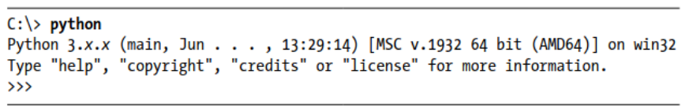

### Nota:

Si no ves esta salida o algo similar, consulta las instrucciones de configuración más detalladas en el Apéndice A. Ingresa la siguiente línea en tu sesión de Python:

```python
print('Hello Python interpreter!')
```

```
Hello Python interpreter!
```

Deberías ver la salida: Hello Python interpreter!

Cada vez que quieras ejecutar un fragmento de código en Python, abre una ventana de comandos y comienza una sesión de terminal de Python. Para cerrar la sesión de terminal, presiona CTRL-Z y luego ENTER, o escribe el comando exit().

### Python en macOS

Las versiones más recientes de macOS no incluyen Python de forma predeterminada, por lo que deberás instalarlo si aún no lo has hecho. En esta sección, instalarás la última versión de Python, luego instalarás VS Code y te asegurarás de que esté configurado correctamente.

### Nota:

Python 2 venía incluido en versiones anteriores de macOS, pero es una versión obsoleta que no deberías usar.

### Verificación de Python 3 en macOS

Abre una ventana de terminal yendo a Aplicaciones ➔ Utilidades ➔ Terminal. También puedes presionar ⌘ + barra espaciadora, escribir terminal y luego presionar ENTER. Para verificar si tienes una versión reciente de Python 3 instalada, escribe:

python3

Lo más probable es que veas un mensaje acerca de instalar las herramientas de línea de comandos para desarrolladores. Es mejor instalar estas herramientas después de instalar Python, así que si aparece ese mensaje, cancela la ventana emergente.

### Resumen

En este capítulo, aprendiste un poco sobre Python en general y lo instalaste en tu sistema, si aún no estaba allí. También instalaste un editor de texto para facilitar la escritura de código en Python. Ejecutaste fragmentos de código en Python en una sesión de terminal y ejecutaste tu primer programa, hello_world.py. Probablemente también aprendiste un poco sobre cómo solucionar problemas (troubleshooting). En el próximo capítulo, aprenderás sobre los diferentes tipos de datos con los que puedes trabajar en tus programas de Python, y comenzarás a utilizar variables.